# University of Edinburgh, Research Training Centre

Using APIs and web scraping

Christopher Barrie

University of Edinburgh | AMWs

# Using APIs and web scraping

In this worksheet, we will see how to access data through an API (the client side). The first example uses a dedicated package, which I created with Juston Ho and Chung-hong Chan, called `academictwitteR`; the second does not rely on a pre-packaged library and instead forces us to write our own `GET` requests to the API. This is the same as any R package or other pre-packaged library is doing—if you looked undernearth the hood of `academictwitteR` this is what you would find!

## Tutorial: APIs

In this tutorial, you will learn how to:

- Get developer access credentials to Twitter
- Get Academic Research Product Track access credentials to Twitter
- Use the `academictwitteR` package to query the Twitter API
- Go through different ways to interact with the Twitter Academic API
- Build our own `GET` requests with the `httr` package

## Setup

In order to use the Twitter Academic Research Product Track you will first need to obtain an authorization token. You will find details about the process of obtaining authorization [here](https://developer.twitter.com/en/solutions/academic-research/application-info).

**In order to gain authorization you first need a Twitter account.**

First, Twitter will ask for details about your academic profile. Per the documentation linked above, they will ask for the following:

> Your full name as it is appears on your institution’s documentation

> Links to webpages that help establish your identity; provide one or more of the following:
> - A link to your profile in your institution’s faculty or student directory
> - A link to your Google Scholar profile
> - A link to your research group, lab or departmental website where you are listed

> Information about your academic institution: its name, country, state, and city

> Your department, school, or lab name

> Your academic field of study or discipline at this institution

> Your current role as an academic (whether you are a graduate student, doctoral candidate, post-doc, professor, research scientist, or other faculty member)

Twitter will then ask for details of the proposed research project. Here, questions include:

> 1. What is the name of your research project?
> 2. Does this project receive funding from outside your academic institution? If yes, please list all your sources of funding.
> 3. In English, describe your research project. Minimum 200 characters.
> 4. In English, describe how Twitter data via the Twitter API will be used in your research project. Minimum 200 characters.
> 5. In English, describe your methodology for analyzing Twitter data, Tweets, and/or Twitter users. Minimum 200 characters.
> 6. Will your research present Twitter data individually or in aggregate?
> 7. In English, describe how you will share the outcomes of your research (include tools, data, and/or other resources you hope to build and share). Minimum 200 characters.
> 8. Will your analysis make Twitter content or derived information available to a government entity?

Once you have gained authorization for your project you will be able to see the new project on your Twitter developer portal. First click on the developer portal as below.

[figure not shown]

Here you will see your new project, and the name you gave it, appear on the left hand side. Once you have associated an App with this project, it will also appear below the name of the project. Here, I have several Apps authorized to query the basic API. I have one App, named “gencap,” that is associated with my Academic Research Product Track project.

[figure not shown]

When you click on the project, you will first see how much of your monthly cap of 10m tweets you have spent. You will also see the App associated with your project below the monthly tweet cap usage information.

[figure not shown]

By clicking on the Settings icons for the App, you will be taken through to the information about the App associated with the project. Here, you will see two options listed, for “Settings” and “Keys and Tokens.”

[figure not shown]

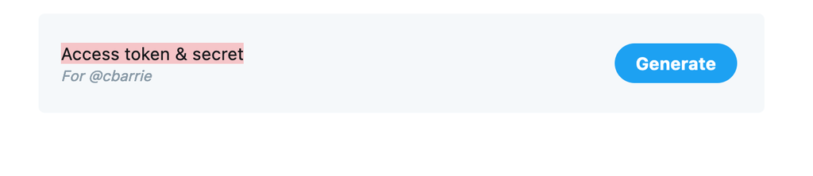

Once you have the Bearer Token, you are ready to use `academictwitteR`!

## Load data and packages

Before proceeding, we’ll load the remaining packages we will need for this section.

```r
library(tidyverse) # loads dplyr, ggplot2, and others
library(academictwitteR) # to query the Academic Research Product Track Twitter v2 API endpoint in R
```

## The Twitter Academic Research Product Track

The Academic Research Product Track permits the user to access larger volumes of data, over a far longer time range, than was previously possible. From the Twitter [documentation](https://developer.twitter.com/en/solutions/academic-research/application-info):

> “The Academic Research product track includes full-archive search, as well as increased access and other v2 endpoints and functionality designed to get more precise and complete data for analyzing the public conversation, at no cost for qualifying researchers. Since the Academic Research track includes specialized, greater levels of access, it is reserved solely for non-commercial use.”

The new “v2 endpoints” refer to the v2 API, introduced around the same time as the new Academic Research Product Track. Full details of the v2 endpoints are available [here](https://developer.twitter.com/en/docs/twitter-api/early-access).

In summary the Academic Research product track allows the authorized user:

1. Access to the full archive of (as-yet-undeleted) tweets published on Twitter
2. A higher monthly tweet cap (10m–or 20x what was previously possible with the standard v1.1 API)
3. Ability to access these data with more precise filters permitted by the v2 API

## Querying the Twitter API with `academictwitteR`

The first task is set authorization credentials with the `set_bearer()` function, which allows the user to store their bearer token in the .Renviron file.

To do so, use:

```r
set_bearer()
```

and enter authorization credentials as below:

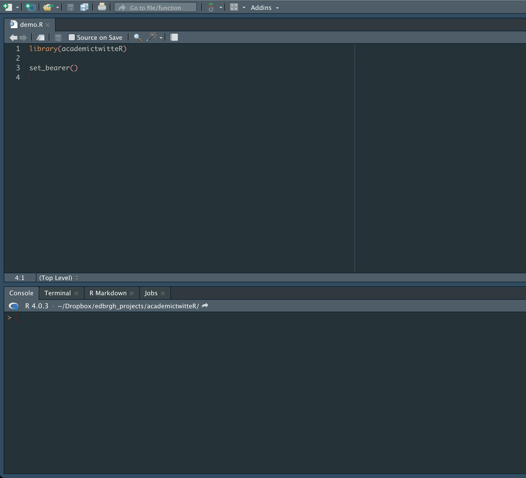

This will mean that the bearer token is automatically called during API calls. It also avoids the inadvisable practice of hard-coding authorization credentials into scripts.